# visualize_data

Catarina Pien

2022-10-04

# Heatwaves Analysis

## Questions

### Logistics

1. What is the definition of a heatwave?
   1. **“The World Meteorological Organization defines it as five or more consecutive days during which the daily maximum temperature surpasses the average maximum temperature by 5 °C (9 °F) or more.”**
   2. **this indicator defines a heat wave as a period of two or more consecutive days where the daily minimum apparent temperature at a particular weather station is higher than the 85th percentile of historical July and August temperatures for that city. Historical July and August baseline temperatures are analyzed for a base period of 1981–2010, which NCEI chose for consistency with other climatology metrics. Using the 85th percentile of July and August temperatures results in a threshold that equates to the nine hottest July and August days in an average year during that 30-year window. These are likely among the nine hottest days of the year.**
   3. What is the average maximum temperature? Delta-wide mean over 10 years? Just July and August?
   4. What is the equivalence of 5C in water temp? Look at relationship of air vs. water?
   5. minimum or maximum temperatures?
2. What stations do we want to look at?

### Analyses/Visualizations

3. When do heatwaves occur? (Seasonality)
4. Where do heatwaves occur? (Regions)
5. Has frequency, duration (hours vs total days in a row), length of heat wave season, intensity changed over time?

### References

- https://www.epa.gov/climate-indicators/climate-change-indicators-heat-waves
- Habeeb, D., J. Vargo, and B. Stone, Jr. 2015. Rising heat wave trends in large U.S. cities. Nat. Hazards 76(3):1651–1665. doi:10.1007/s11069-014-1563-z.

## Read data

[figure not shown]

```
## Rows: 918,425
## Columns: 7
## $ station   <chr> "MRZ", "MRZ", "MRZ", "MRZ", "MRZ", "MRZ", "MRZ", "MRZ", "MRZ…
## $ datetime  <dttm> 2002-01-04 23:57:00, 2004-01-05 23:55:00, 2005-01-06 23:54:…
## $ airtemp_F <dbl> 32, 54, 32, 53, 56, 54, 55, 20, 20, 19, 19, 19, 19, 18, 18, …
## $ date      <date> 2002-01-04, 2004-01-05, 2005-01-06, 2006-01-07, 2006-01-08,…
## $ month     <dbl> 1, 1, 1, 1, 1, 1, 1, 8, 8, 8, 8, 8, 8, 8, 8, 8, 8, 8, 8, 8, …
## $ year      <dbl> 2002, 2004, 2005, 2006, 2006, 2007, 2007, 2008, 2008, 2008, …
## $ airtemp_C <dbl> 0.0, 12.2, 0.0, 11.7, 13.3, 12.2, 12.8, -6.7, -6.7, -7.2, -7…
```

```
## Rows: 606,534
## Columns: 17
## $ station     <chr> "ANH", "ANH", "ANH", "ANH", "ANH", "ANH", "ANH", "ANH", "A…
## $ datetime    <dttm> 2009-10-01 00:00:00, 2009-10-01 01:00:00, 2009-10-01 02:0…
## $ Date        <date> 2009-10-01, 2009-10-01, 2009-10-01, 2009-10-01, 2009-10-0…
## $ wtemp       <dbl> 20.3, 20.2, 20.2, 20.1, 20.1, 20.1, 20.2, 20.0, 19.8, 19.8…
## $ Year        <dbl> 2009, 2009, 2009, 2009, 2009, 2009, 2009, 2009, 2009, 2009…
## $ Month       <dbl> 10, 10, 10, 10, 10, 10, 10, 10, 10, 10, 10, 10, 10, 10, 10…
## $ yDay        <dbl> 274, 274, 274, 274, 274, 274, 274, 274, 274, 274, 274, 274…
## $ WY          <dbl> 2010, 2010, 2010, 2010, 2010, 2010, 2010, 2010, 2010, 2010…
## $ cluster     <int> 1, 1, 1, 1, 1, 1, 1, 1, 1, 1, 1, 1, 1, 1, 1, 1, 1, 1, 1, 1…
## $ Region      <fct> Sac River, Sac River, Sac River, Sac River, Sac River, Sac…
## $ StationName <chr> "SAN JOAQUIN RIVER AT ANTIOCH", "SAN JOAQUIN RIVER AT ANTI…
## $ HabitatType <fct> "Tidal River Channel (brackish)", "Tidal River Channel (br…
## $ WYType2_Sac <chr> "Mid", "Mid", "Mid", "Mid", "Mid", "Mid", "Mid", "Mid", "M…
## $ Index_c     <dbl> 10.63, 10.63, 10.63, 10.63, 10.63, 10.63, 10.63, 10.63, 10…
## $ totalDays   <int> 363, 363, 363, 363, 363, 363, 363, 363, 363, 363, 363, 363…
## $ nMonth      <int> 12, 12, 12, 12, 12, 12, 12, 12, 12, 12, 12, 12, 12, 12, 12…
## $ nYear       <int> 10, 10, 10, 10, 10, 10, 10, 10, 10, 10, 10, 10, 10, 10, 10…
```

```
## [1] "ANH" "MAL" "MRZ" "MSD" "RRI" "RVB" "SJR"
```

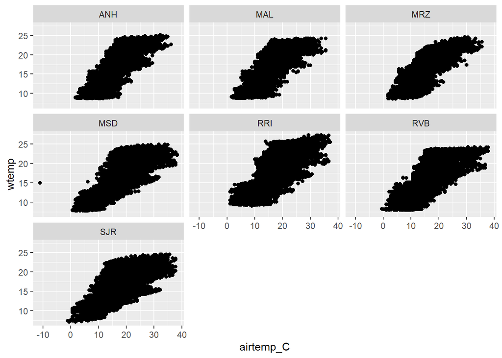

```r
ggplot(subset) + geom_point(aes(x = airtemp_C, y = wtemp)) + facet_wrap(~station)
```

## Calculate long term averages

Compare different averages

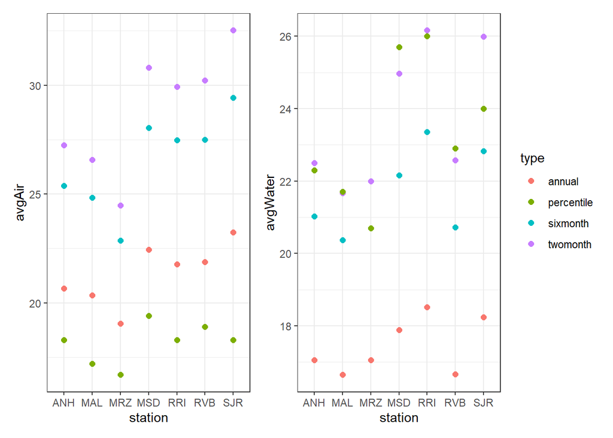

```r
plot_air <- ggplot(alldata) + geom_point(aes(station, avgAir, color = type), size = 2) + theme_bw()
plot_water <- ggplot(alldata) + geom_point(aes(station, avgWater, color = type), size = 2) + theme_bw()

library(patchwork)
plot_air + plot_water + plot_layout(guides = "collect")
```